# Results

IPM

### Feature selection

#### LASSO

1. The LASSO includes choosing the regular parameter $\lambda$, determining the number of the feature.

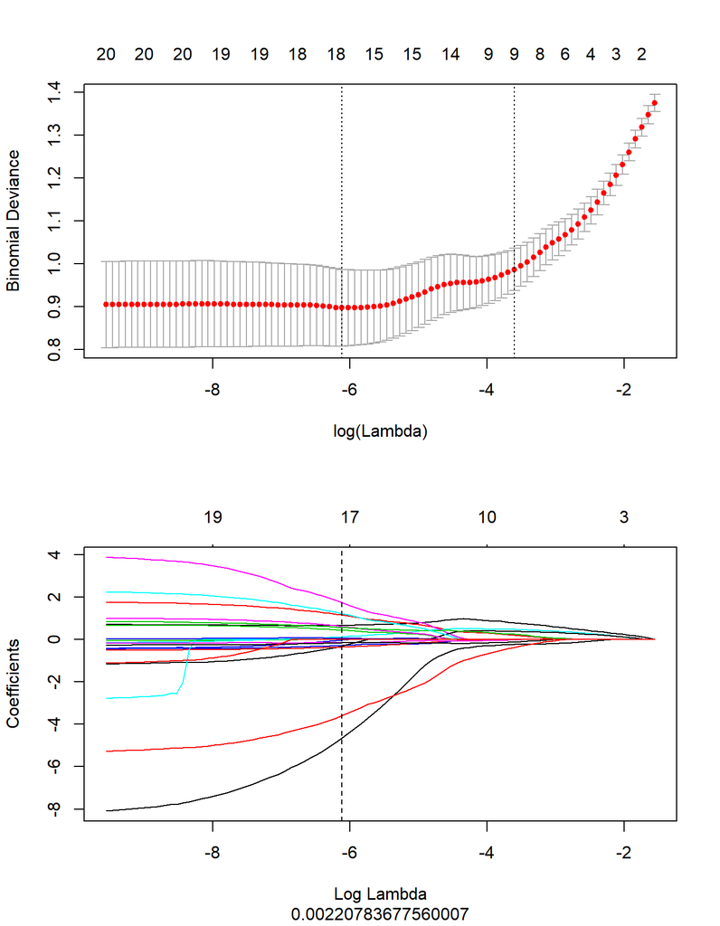

2. After the number of feature determined, the most predictive subset of feature was chosen and the corresponding coefficients were evaluated.

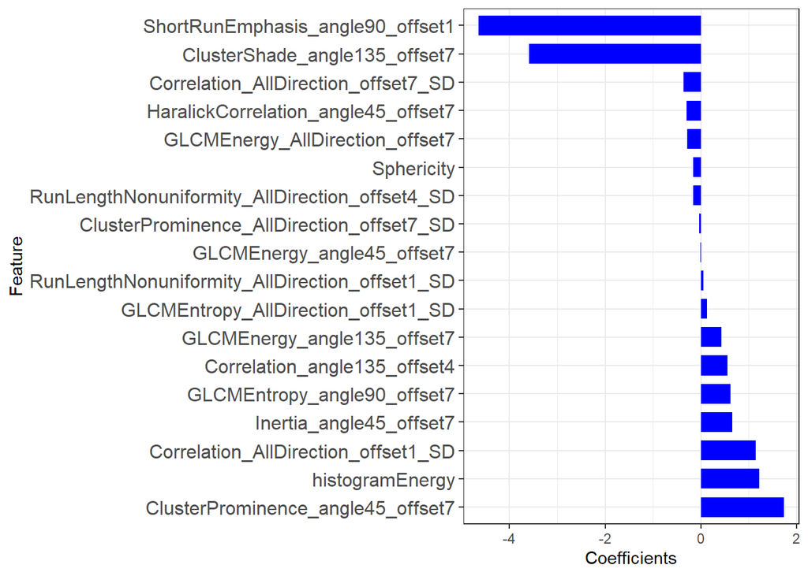

### Radiomics signature construction

#### Radscore

Radscore was calculated by summing the selected features weighted by their coefficients. The final formula of radscore is:

[output not shown]

And we compared the radscores from class 0 and class 1 on training group and test group respectively.

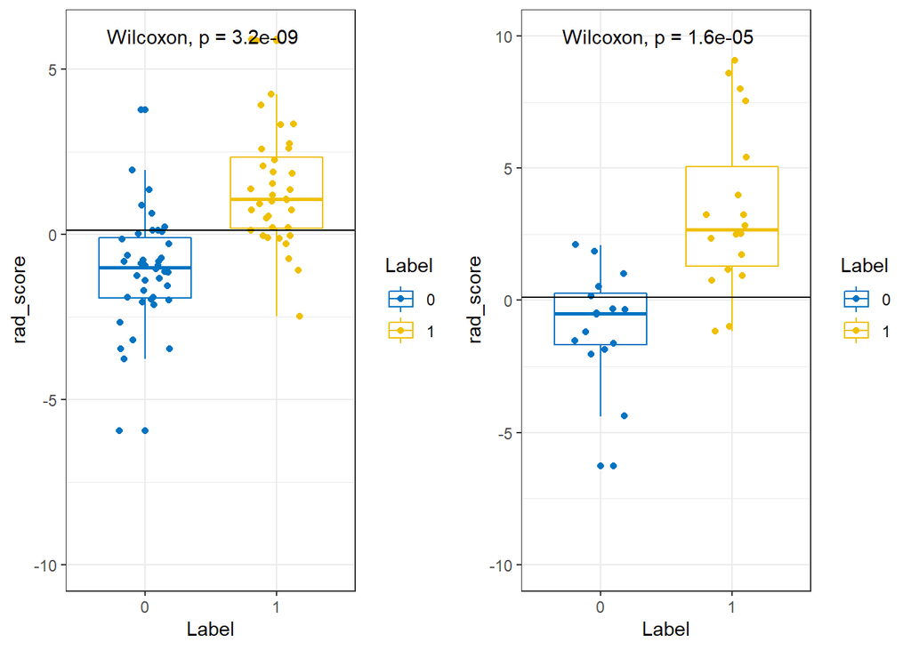

#### Radiomics valiation

We used ROC analysis to evaluate the performance of the model：

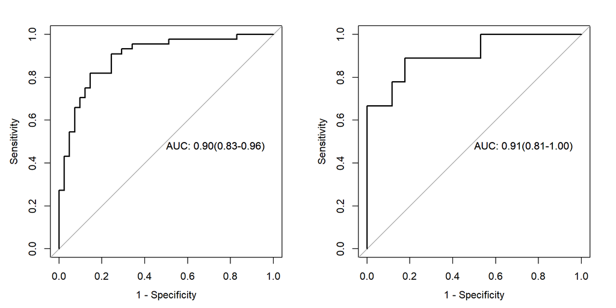

Based on Youden Index, other parameters were calculated as following:

Result of radiomics

|  | Accuracy | AccuracyLower | AccuracyUpper | Sensitivity | Specificity | Pos.Pred.Value | Neg.Pred.Value |
| --- | --- | --- | --- | --- | --- | --- | --- |
| Train | 0.8705882 | 0.7802336 | 0.9335901 | 0.8837209 | 0.8571429 | 0.8636364 | 0.8780488 |
| Test | 0.8000000 | 0.6306212 | 0.9155940 | 0.7391304 | 0.9166667 | 0.9444444 | 0.6470588 |

### Nomogram build

#### Clinicopathological factors and radscore selection

```
##       Variable Units OddsRatio      Lower     Upper       Pvalue
## 1:        Size       1.1772050 1.02860022 1.3472792 0.0178106239
## 2:       Solid       1.4075960 1.13969119 1.7384765 0.0015043910
## 3:       Ratio       1.0556271 1.01578804 1.0970287 0.0058148963
## 4: Attenuation       1.0063487 1.00261354 1.0100978 0.0008507940
## 5:  Lobulation       0.3405573 0.13371952 0.8673323 0.0239221827
## 6: Spiculation       0.1896552 0.07479165 0.4809238 0.0004619321
## 7:       Shape       2.2422145 0.94079961 5.3438861 0.0684177473
## 8:      Vessel       0.2688172 0.10633171 0.6795968 0.0054995774
## 9: Bronchogram       0.2470588 0.09026071 0.6762418 0.0064998518
```

```
##     Variable Units OddsRatio       CI.95     p-value
##         Size            1.40 [1.13;1.74]   0.0023801
##        Ratio            1.11 [1.05;1.17]   0.0004499
##  Attenuation            1.01 [1.00;1.01]   0.0010682
##  Spiculation            0.13 [0.03;0.54]   0.0049599
##       Vessel            0.36 [0.10;1.30]   0.1183220
```

#### nomogram

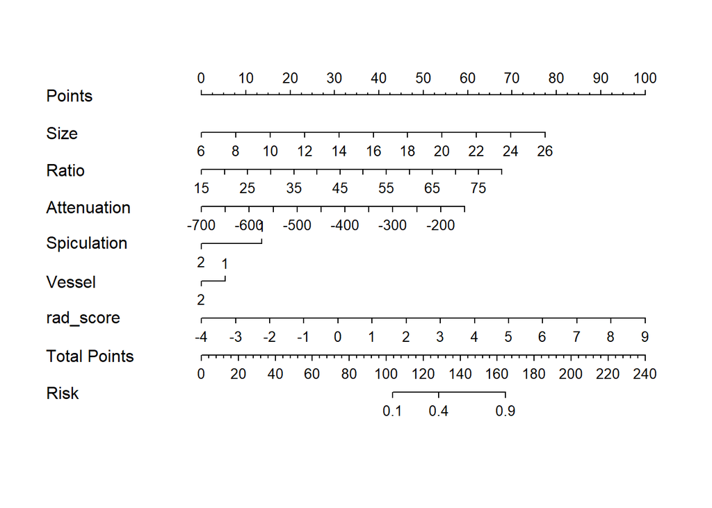

#### nomogram validation

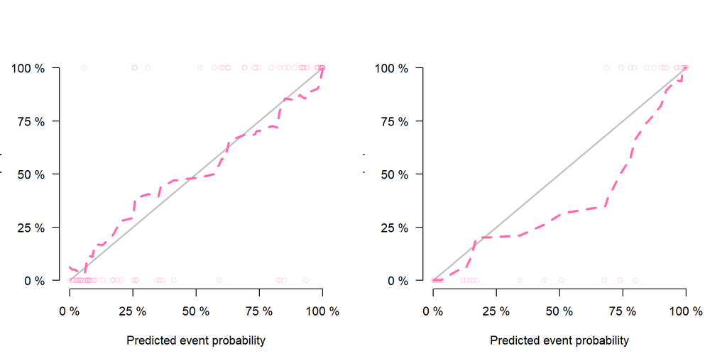

Hosmer-Lemeshow Test results:

```
## $C
##
##  Hosmer-Lemeshow C statistic
##
## data:  cal_train$Frame$lrm and cal_train$Frame$jack
## X-squared = 8.6196, df = 8, p-value = 0.3754
##
##
## $H
##
##  Hosmer-Lemeshow H statistic
##
## data:  cal_train$Frame$lrm and cal_train$Frame$jack
## X-squared = 10.88, df = 8, p-value = 0.2086
```

```
## $C
##
##  Hosmer-Lemeshow C statistic
##
## data:  cal_test$Frame$lrm and cal_test$Frame$jack
## X-squared = 5.1141, df = 8, p-value = 0.7453
##
##
## $H
##
##  Hosmer-Lemeshow H statistic
##
## data:  cal_test$Frame$lrm and cal_test$Frame$jack
## X-squared = 5.1604, df = 8, p-value = 0.7403
```

Finally, we used decision curve to evaluate the clinical usefullness of the model:

```
## Note: When multiple decision curves are plotted, decision curves for 'All' are calculated using the prevalence from the first DecisionCurve object in the list provided.
```

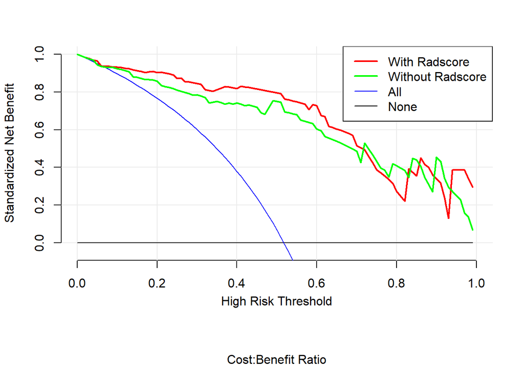